# NetCDF, OPeNDAP and ERDDAP

# NetCDF Basics

## Data Cube

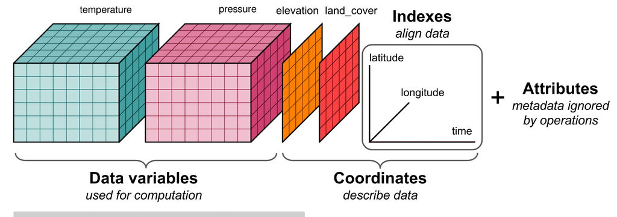

Data Cubes

## Dimensions

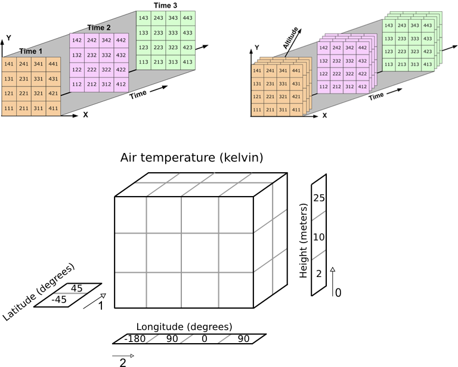

Dimensions

## Array Space

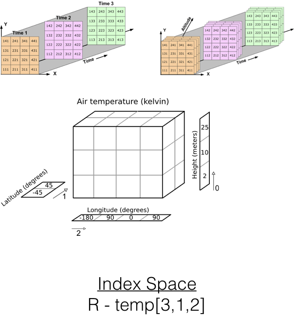

ArraySpace

In R terms, just think of a multi-dimensional array, with dimension names and attributes, but the dimensions themselves have values (sometime put in as attributes or dimensions).

## Coordinate Space

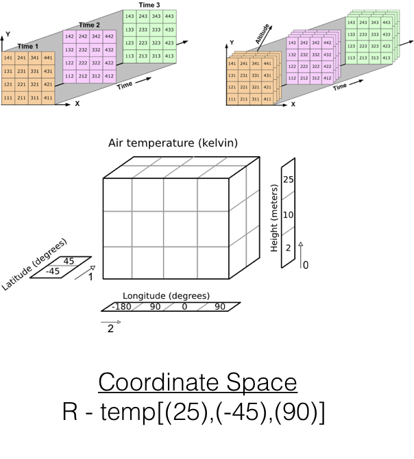

CoordinateSpace

# Accessing netCDF files

- “Open” file (create a pointer to start of file)
- Get attribues (metadata) about the file and variables
- Create a pointer to a particular parameter
- Access a (subset of) that parameter
- “Close” the file

# Structure of a netCDF File

```r
system2('/sw/bin/ncdump', args = '-h poes.nc')
```

netcdf poes { dimensions: time = 6 ; altitude = 1 ; latitude = 31 ; longitude = 51 ; variables: double time(time) ; time:_CoordinateAxisType = “Time” ; time:actual_range = 1410825600., 1423958400. ; time:axis = “T” ; time:fraction_digits = 0 ; time:ioos_category = “Time” ; time:long_name = “Centered Time” ; time:standard_name = “time” ; time:time_origin = “01-JAN-1970 00:00:00” ; time:units = “seconds since 1970-01-01T00:00:00Z” ; double altitude(altitude) ; altitude:_CoordinateAxisType = “Height” ; altitude:_CoordinateZisPositive = “up” ; altitude:actual_range = 0., 0. ; altitude:axis = “Z” ; altitude:fraction_digits = 0 ; altitude:ioos_category = “Location” ; altitude:long_name = “Altitude” ; altitude:positive = “up” ; altitude:standard_name = “altitude” ; altitude:units = “m” ; double latitude(latitude) ; latitude:_CoordinateAxisType = “Lat” ; latitude:actual_range = 36., 39. ; latitude:axis = “Y” ; latitude:coordsys = “geographic” ; latitude:fraction_digits = 1 ; latitude:ioos_category = “Location” ; latitude:long_name = “Latitude” ; latitude:point_spacing = “even” ; latitude:standard_name = “latitude” ; latitude:units = “degrees_north” ; double longitude(longitude) ; longitude:_CoordinateAxisType = “Lon” ; longitude:actual_range = 235., 240. ; longitude:axis = “X” ; longitude:coordsys = “geographic” ; longitude:fraction_digits = 1 ; longitude:ioos_category = “Location” ; longitude:long_name = “Longitude” ; longitude:point_spacing = “even” ; longitude:standard_name = “longitude” ; longitude:units = “degrees_east” ; float sst(time, altitude, latitude, longitude) ; sst:_FillValue = -9999999.f ; sst:colorBarMaximum = 32. ; sst:colorBarMinimum = 0. ; sst:coordsys = “geographic” ; sst:fraction_digits = 1 ; sst:ioos_category = “Temperature” ; sst:long_name = “Sea Surface Temperature” ; sst:missing_value = -9999999.f ; sst:standard_name = “sea_surface_temperature” ; sst:units = “degree_C” ;

// global attributes: :acknowledgement = “NOAA NESDIS COASTWATCH, NOAA SWFSC ERD” ; :cdm_data_type = “Grid” ; :composite = “true” ; :contributor_name = “NOAA NESDIS OSDPD” ; :contributor_role = “Source of level 2 data.” ; :Conventions = “COARDS, CF-1.6, Unidata Dataset Discovery v1.0” ; :creator_email = “dave.foley@noaa.gov” ; :creator_name = “NOAA CoastWatch, West Coast Node” ; :creator_url = “http://coastwatch.pfel.noaa.gov” ; :date_created = “2015-02-03Z” ; :date_issued = “2015-02-03Z” ; :Easternmost_Easting = 240. ; :geospatial_lat_max = 39. ; :geospatial_lat_min = 36. ; :geospatial_lat_resolution = 0.1 ; :geospatial_lat_units = “degrees_north” ; :geospatial_lon_max = 240. ; :geospatial_lon_min = 235. ; :geospatial_lon_resolution = 0.1 ; :geospatial_lon_units = “degrees_east” ; :geospatial_vertical_max = 0. ; :geospatial_vertical_min = 0. ; :geospatial_vertical_positive = “up” ; :geospatial_vertical_units = “m” ; :history = “NOAA NESDIS OSDPD”, “2015-02-03T21:00:15Z NOAA CoastWatch (West Coast Node) and NOAA SFSC ERD”, “2015-03-23T20:07:38Z http://oceanwatch.pfeg.noaa.gov/thredds/dodsC/satellite/AG/ssta/mday\n”, “2015-03-23T20:07:38Z [http://coastwatch.pfeg.noaa.gov/erddap/griddap/erdAGsstamday.nc?sst[last-5:1:last]](http://coastwatch.pfeg.noaa.gov/erddap/griddap/erdAGsstamday.nc?sst%5Blast-5:1:last%5D)[(0.0):1:(0.0)][(36):1:(39)][(235):1:(240)]” ; :infoUrl = “http://coastwatch.pfeg.noaa.gov/infog/AG_ssta_las.html” ; :institution = “NOAA CoastWatch, West Coast Node” ; :keywords = “Oceans > Ocean Temperature > Sea Surface Temperature,”, “avhrr, coastwatch, day, degrees, gac, global, monthly, night, noaa, ocean, oceans, poes, sea, sea_surface_temperature, sst, surface, temperature, wcn” ; :keywords_vocabulary = “GCMD Science Keywords” ; :license = “The data may be used and redistributed for free but is not intended”, “for legal use, since it may contain inaccuracies. Neither the data”, “Contributor, ERD, NOAA, nor the United States Government, nor any”, “of their employees or contractors, makes any warranty, express or”, “implied, including warranties of merchantability and fitness for a”, “particular purpose, or assumes any legal liability for the accuracy,”, “completeness, or usefulness, of this information.” ; :Metadata_Conventions = “COARDS, CF-1.6, Unidata Dataset Discovery v1.0” ; :naming_authority = “gov.noaa.pfel.coastwatch” ; :Northernmost_Northing = 39. ; :origin = “NOAA NESDIS OSDPD” ; :processing_level = “3” ; :project = “CoastWatch (http://coastwatch.noaa.gov/)” ; :projection = “geographic” ; :projection_type = “mapped” ; :references = “NOAA POES satellites information: http://www.oso.noaa.gov/poes/index.htm . Processing link: http://www.osdpd.noaa.gov/PSB/PSB.html . Processing reference: Walton C. C., W. G. Pichel, J. F. Sapper, D. A. May. The development and operational application of nonlinear algorithms for the measurement of sea surface temperatures with the NOAA polar-orbiting environmental satellites. J.G.R., 103: (C12) 27999-28012, 1998. Cloudmask reference: Stowe, L. L., P. A. Davis, and E. P. McClain. Scientific basis and initial evaluation of the CLAVR-1 global clear/cloud classification algorithm for the advanced very high resolution radiometer. J. Atmos. Oceanic Technol., 16, 656-681. 1999. Calibration and Validation: Li, X., W. Pichel, E. Maturi, P. Clemente-Colon, and J. Sapper. Deriving the operational nonlinear multi-channel sea surface temperature algorithm coefficients for NOAA-15 AVHRR/3. International Journal of Remote Sensing, Volume 22, No. 4, 699 - 704, March 2001a. Calibration and Validation: Li, X, W. Pichel, P. Clemente-Colon, V. Krasnopolsky, and J. Sapper. Validation of coastal sea and lake surface temperature measurements derived from NOAA/AVHRR Data. International Journal of Remote Sensing, Vol. 22, No. 7, 1285-1303, 2001b.” ; :satellite = “POES” ; :sensor = “AVHRR GAC” ; :source = “satellite observation: POES, AVHRR GAC” ; :sourceUrl = “http://oceanwatch.pfeg.noaa.gov/thredds/dodsC/satellite/AG/ssta/mday” ; :Southernmost_Northing = 36. ; :standard_name_vocabulary = “CF-12” ; :summary = “NOAA CoastWatch provides sea surface temperature (SST) products derived from NOAA's Polar Operational Environmental Satellites (POES). This data provides global area coverage at 0.1 degrees resolution. Measurements are gathered by the Advanced Very High Resolution Radiometer (AVHRR) instrument, a multiband radiance sensor carried aboard the NOAA POES satellites.” ; :time_coverage_end = “2015-02-15T00:00:00Z” ; :time_coverage_start = “2014-09-16T00:00:00Z” ; :title = “SST, POES AVHRR, GAC, Global, Day and Night (Monthly Composite)” ; :Westernmost_Easting = 235. ; }